# BIOS6611-Homework6-20191003

Randy

10/3/2019

##### Question1.i.a

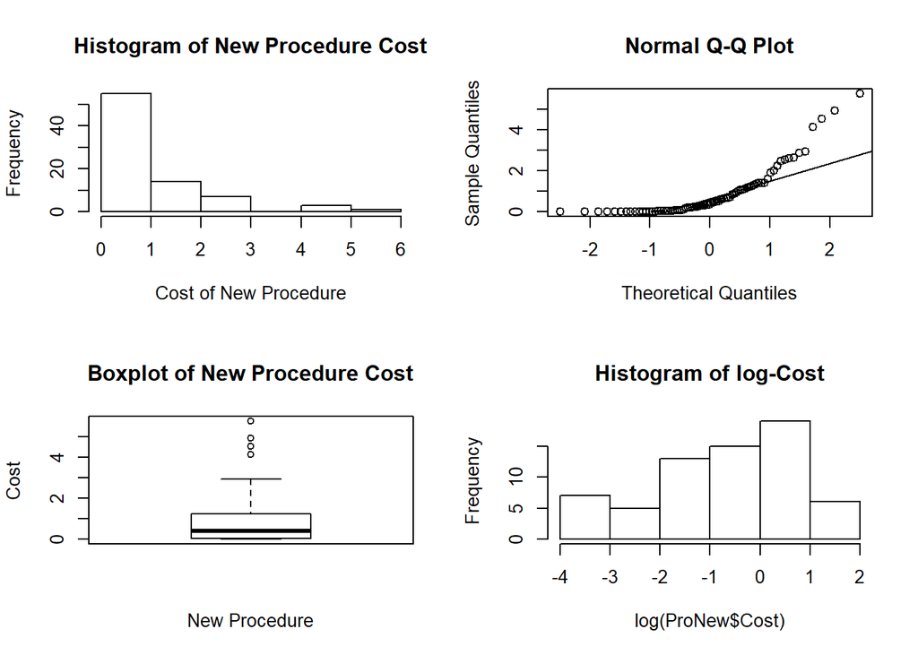

```r
ProCost <- read.csv("C:/Users/Goodgolden5/Desktop/BIOS6611-Alexander Kaizer/BIOS6611-Dataset/ProcedureCost.csv")
ProNew <- ProCost[ProCost$Procedure == 2, ]
par(mfrow = c(2,2))
hist(ProNew$Cost, main = "Histogram of New Procedure Cost", xlab = "Cost of New Procedure")
qqnorm(ProNew$Cost); qqline(ProNew$Cost)
boxplot(ProNew$Cost, xlab  = "New Procedure", ylab = "Cost", main = "Boxplot of New Procedure Cost")
hist(log(ProNew$Cost), main = "Histogram of log-Cost")
```

##### Question1.i.b

The data was not normal distributed, not bell-shaped, not symmetric, and terriblly right skewed.

##### Question1.i.c

```r
summary(ProNew$Cost)
```

```
##    Min. 1st Qu.  Median    Mean 3rd Qu.    Max.
##  0.0000  0.0400  0.3850  0.8816  1.2075  5.7500
```

```r
ObMean <- mean(ProNew$Cost)
ObMed <- median(ProNew$Cost)
ObSD <- sd(ProNew$Cost)
cat("The observation mean is", ObMean, "\n")
```

```
## The observation mean is 0.881625
```

```r
cat("The observation median is", ObMed, "\n")
```

```
## The observation median is 0.385
```

```r
cat("The observation standard deviation is", ObSD, "\n")
```

```
## The observation standard deviation is 1.210242
```

##### Question1.i.d

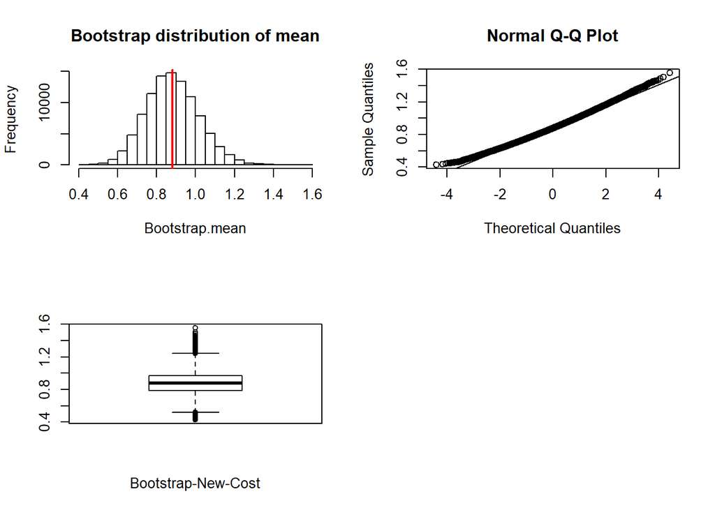

```r
set.seed(seed = 555)
par(mfrow = c(2,2))
N <- 10^5
Bootstrap.mean <- vector("numeric", length(ProNew$Cost))
for(i in seq_along(1:N)){
  Bootstrap <- sample(ProNew$Cost, length(ProNew$Cost), replace = T)
  Bootstrap.mean[i] <- mean(Bootstrap)
}
hist(Bootstrap.mean, main = "Bootstrap distribution of mean")
abline(v = mean(Bootstrap.mean), col = "red", lwd = 2)
qqnorm(Bootstrap.mean)
qqline(Bootstrap.mean)
boxplot(Bootstrap.mean, xlab = "Bootstrap-New-Cost")
```

##### Question1.i.e Describe the shape and spread

The distribution of the Bootstrap mean are symmetrical, normal-like distributed.

##### Question1.i.f

```r
BootstrapMean <- mean(Bootstrap.mean)
BootstrapMed <- median(Bootstrap.mean)
BootstrapSD <- sd(Bootstrap.mean)
BootstrapBias <- BootstrapMean-ObMean
cat("The Bootstrap mean is", BootstrapMean, "\n")
```

```
## The Bootstrap mean is 0.8818924
```

```r
cat("The Bootstrap median is", BootstrapMed, "\n")
```

```
## The Bootstrap median is 0.87675
```

```r
cat("The Bootstrap standard deviation is", BootstrapSD, "\n")
```

```
## The Bootstrap standard deviation is 0.1342266
```

```r
cat("The Bootstrap bias is", BootstrapBias, "\n")
```

```
## The Bootstrap bias is 0.0002674225
```

##### Question1.i.g

```r
LL <- BootstrapMean-1.96*BootstrapSD
UL <- BootstrapMean+1.96*BootstrapSD
LCI <- sum(Bootstrap.mean<LL)/N
UCI <- sum(Bootstrap.mean>UL)/N
cat("Coverage of CI is", LL, "to", UL, "\n" )
```

```
## Coverage of CI is 0.6188082 to 1.144977
```

```r
BootstrapCI <- quantile(Bootstrap.mean, c(0.025, 0.975))
cat("Bootstrap precentile 95% CI is", BootstrapCI, "\n")
```

```
## Bootstrap precentile 95% CI is 0.6339969 1.15925
```

##### Question1.ii.a

```r
ProNew <- ProCost[ProCost$Procedure == 2, ]
ProOld <- ProCost[ProCost$Procedure == 1, ]
NewMean <- mean(ProNew$Cost); NewSD <- sd(ProNew$Cost); NewL <- length(ProNew$Cost)
cat("The New Procedure mean is", NewMean, "\n")
```

```
## The New Procedure mean is 0.881625
```

```r
cat("The New Procedure standard is", NewSD, "\n")
```

```
## The New Procedure standard is 1.210242
```

```r
cat("The New Procedure length is", NewL, "\n","\n")
```

```
## The New Procedure length is 80
##
```

```r
OldMean <- mean(ProOld$Cost); OldSD <- sd(ProOld$Cost); OldL <- length(ProOld$Cost)
cat("The Old Procedure mean is", OldMean, "\n")
```

```
## The Old Procedure mean is 1.29325
```

```r
cat("The Old Procedure standard is", OldSD, "\n")
```

```
## The Old Procedure standard is 1.370335
```

```r
cat("The Old Procedure length is", OldL, "\n")
```

```
## The Old Procedure length is 120
```

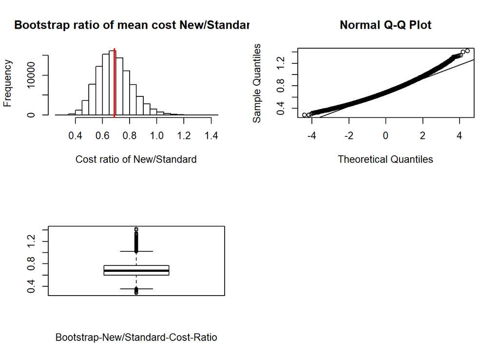

```r
BootRatio <- vector("numeric", N)
for (i in 1:N){
  BootNew <- sample(ProNew$Cost, NewL, replace = TRUE)
  BootOld <- sample(ProOld$Cost, OldL, replace = TRUE)
  BootRatio[i] <- (mean(BootNew)/mean(BootOld))
}
par(mfrow = c(2,2))
hist(BootRatio, main = "Bootstrap ratio of mean cost New/Standard", xlab = "Cost ratio of New/Standard")
abline(v = mean(BootRatio), col = "red", lwd = 2)
qqnorm(BootRatio); qqline(BootRatio)
boxplot(BootRatio, xlab = "Bootstrap-New/Standard-Cost-Ratio")
```

```r
ObRatio <- NewMean/OldMean
BootRatioMean <- mean(BootRatio)
BootRatioBias <- ObRatio-BootRatioMean
BootRatioSD <- sd(BootRatio)
BootRule <- BootRatioBias/BootRatioSD
cat("The Real Ratio of mean cost is", ObRatio, "\n")
```

```
## The Real Ratio of mean cost is 0.6817127
```

```r
cat("The Bootstrap Ratio of mean cost is", BootRatioMean, "\n")
```

```
## The Bootstrap Ratio of mean cost is 0.6884147
```

```r
cat("The Bias of mean cost ratio is", BootRatioBias, "\n")
```

```
## The Bias of mean cost ratio is -0.006701957
```

```r
cat("The Standard Error of mean cost ratio is", BootRatioSD, "\n")
```

```
## The Standard Error of mean cost ratio is 0.1256551
```

```r
cat("The Thumb Rule value is", BootRule, "< 0.1","\n")
```

```
## The Thumb Rule value is -0.05333613 < 0.1
```

##### Question1.ii.b

```r
LL <- BootRatioMean-1.96*BootRatioSD
UL <- BootRatioMean+1.96*BootRatioSD
cat("Bootstrap Cost Ratio Coverage of CI is", LL, "to", UL, "\n" )
```

```
## Bootstrap Cost Ratio Coverage of CI is 0.4421307 to 0.9346987
```

```r
BootRatioCI <- quantile(BootRatio, c(0.025, 0.975))
cat("Bootstrap precentile 95% CI is", BootRatioCI, "\n")
```

```
## Bootstrap precentile 95% CI is 0.4687891 0.9598805
```

Because the distribution of the bootstrap estimate for Cost ratio is not strictly normal distributed, the approximation from normal distribution is not as accurate as the quantile of boostrap estimation.

##### Question1.iii.a

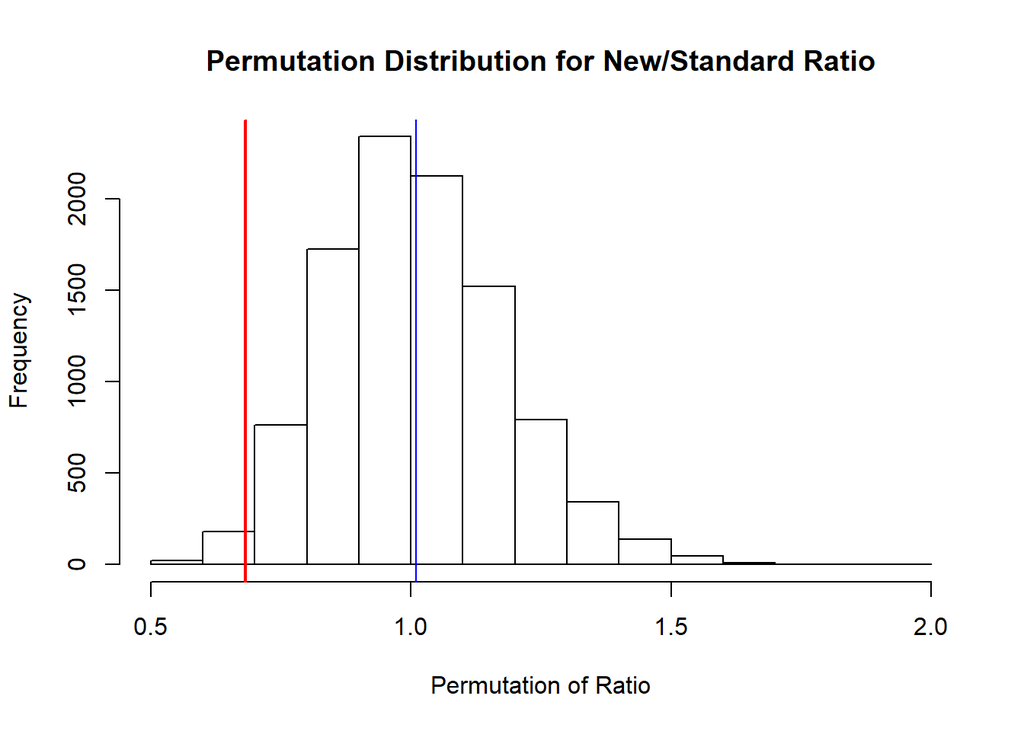

```r
set.seed(seed = 555)
P <- 10^4-1
PerRatio <- vector("numeric", P)
for(i in seq_along(1:P)){
  Permutation <- sample(ProCost$Cost, replace = F)
  PerOld <- Permutation[1:OldL]
  PerNew <- Permutation[(OldL+1):(OldL+NewL)]
  PerRatio[i] <- mean(PerNew)/mean(PerOld)
}
PerRatioMean <- mean(PerRatio)
hist(PerRatio, main = "Permutation Distribution for New/Standard Ratio", xlab = "Permutation of Ratio")
abline(v = ObRatio, col = "red", lwd = 2)
abline(v = PerRatioMean, col = "blue", lwd = 1)
```

```r
PerRatiopvalue <- 2*(sum(PerRatioMean >= ObRatio)+1)/(P + 1)
Perttest <- t.test(PerRatio, mu = ObRatio, alternative = "two.sided", paired = FALSE)
cat("The permutation two-sided p-value is", PerRatiopvalue, ".\n")
```

```
## The permutation two-sided p-value is 4e-04 .
```

```r
cat("The permutation p-value based on t-test is too small and near to", Perttest$p.value,".\n")
```

```
## The permutation p-value based on t-test is too small and near to 0 .
```

Based on what the result from homework3, we can see the Cost between New procedure and the Standard procedure are totally different from each other. Hence the null hypothesis, statmented of these two groups distribution are the equal, is rejected. This work is consistent with the result we got weeks before. To use permutation to simulate the New/Standard Ratio is not a good idea for this project.

```r
CostTable <- matrix(nrow = 2, byrow = T, c(48, 72, 15, 65), dimnames = list(c("Old", "New"), c("Zero", "NonZero")))
prop.table(CostTable, margin = 1)
```

```
##       Zero NonZero
## Old 0.4000  0.6000
## New 0.1875  0.8125
```

```r
CostTable
```

```
##     Zero NonZero
## Old   48      72
## New   15      65
```

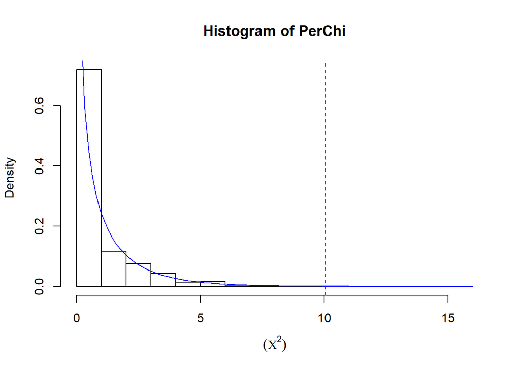

```r
library(epitools)
CostExpand <- expand.table(CostTable)
Chisq <- function(Obs){
  Exp <- outer(rowSums(Obs),colSums(Obs))/sum(Obs)
  sum((Obs-Exp)^2/Exp)
}
Procedure <- CostExpand[, 1]
Cost <- CostExpand[, 2]
ObsV <- Chisq(table(Procedure, Cost))
PerChi <- vector("numeric", P)
for(i in seq_along(1:P)){
  ProcPer <- sample(Procedure, replace = F)
  PerTable <-table(ProcPer, Cost)
  PerChi[i] <- Chisq(PerTable)
}
hist(PerChi, freq = F, xlab = expression((Chi^2), main = "Permutation Distribution for chi-Square"))
abline(v = ObsV, col = "red", lty = 2)
curve(dchisq(x, 1), add = T, col = "blue", lwd = 1)
```

```r
Prepvalue <- (sum(PerChi >= ObsV)+1)/(P+1)
Obspvalue <- 1 - pchisq(ObsV, df = 1)
cat("The permutation distribution p-value is", Prepvalue, "\n")
```

```
## The permutation distribution p-value is 0.0022
```

```r
cat("The Chi-square distribution p-value is", Obspvalue, "\n")
```

```
## The Chi-square distribution p-value is 0.001527466
```

##### Question1.iii.b

Definitely not, the assumptions of permutation and bootstrap are totally different. Normally we do not use both of them together. Moreover, permutation of the result is probably not a good choice for New/Standard cost ratio.

##### Question2.i

```r
library(survival)
library(epiR)
CostTable <- matrix(nrow = 2, byrow = T, c(65, 15, 72, 48), dimnames = list(c("Old", "New"), c("Zero", "NonZero")))
epi.2by2(CostTable)
```

```
##              Outcome +    Outcome -      Total        Inc risk *
## Exposed +           65           15         80              81.2
## Exposed -           72           48        120              60.0
## Total              137           63        200              68.5
##                  Odds
## Exposed +        4.33
## Exposed -        1.50
## Total            2.17
##
## Point estimates and 95% CIs:
## -------------------------------------------------------------------
## Inc risk ratio                               1.35 (1.13, 1.62)
## Odds ratio                                   2.89 (1.48, 5.64)
## Attrib risk *                                21.25 (9.00, 33.50)
## Attrib risk in population *                  8.50 (-2.38, 19.38)
## Attrib fraction in exposed (%)               26.15 (11.58, 38.32)
## Attrib fraction in population (%)            12.41 (4.35, 19.79)
## -------------------------------------------------------------------
##  Test that odds ratio = 1: chi2(1) = 10.045 Pr>chi2 = 0.002
##  Wald confidence limits
##  CI: confidence interval
##  * Outcomes per 100 population units
```

##### Question2.ii.a

```r
ChiNate <- chisq.test(CostTable, correct = FALSE); ChiNate
```

```
##
##  Pearson's Chi-squared test
##
## data:  CostTable
## X-squared = 10.045, df = 1, p-value = 0.001527
```

```r
ChiYate <- chisq.test(CostTable, correct = TRUE); ChiYate
```

```
##
##  Pearson's Chi-squared test with Yates' continuity correction
##
## data:  CostTable
## X-squared = 9.0845, df = 1, p-value = 0.002578
```

```r
Fisher <- fisher.test(CostTable); Fisher
```

```
##
##  Fisher's Exact Test for Count Data
##
## data:  CostTable
## p-value = 0.001799
## alternative hypothesis: true odds ratio is not equal to 1
## 95 percent confidence interval:
##  1.420827 6.074658
## sample estimates:
## odds ratio
##    2.87396
```

```r
Mcnemar <- mcnemar.test(CostTable, correct=TRUE); Mcnemar
```

```
##
##  McNemar's Chi-squared test with continuity correction
##
## data:  CostTable
## McNemar's chi-squared = 36.046, df = 1, p-value = 1.927e-09
```

##### Question2.ii.b

McNemar’s chi-squared test is based on pairwaise the samples, but clearly the procedure’s costs are not paired data. So McNemar is the first ruled out;

For large samples Fisher’s exact test is computationally intensive; but both Fisher’s exact p-value and $^2 $ test p-value provide similar results. Because we are fit the continuous data (Cost) into discrete data, the $^2 $ test p-value with Yate’s correction will be prefered.

##### Question2.ii.c

According to the results from $^2 $ test and Fisher’s exact test, the p-value is less than 0.05. So we can reject the null hypothesis. The different procedures do affect the cost of the treatment.